# Western Boreal Land Cover Classes

Isolde Lane Shaw, Ana Raymundo and Steve Cumming

12/3/2020

# 1 Introduction

Ecosystems are complex and highly integrated entities defined by assemblages of species, the physical environment, and the processes that regulate them. Vegetation heterogeneity has a strong influence on the diversity and distribution of other species. Structurally complex habitats may provide more niches and different ways of exploiting the environmental resources and increasing species diversity (Tews et al. 2004; Lawler et al. 2004).

The complexity and heterogeneity of the land cover and vegetation in the Western Boreal Project (WBP) area creates challenges in effective modeling due to finite data resources. In order to draw well-substantiated conclusions on the diversity and abundance of bird species across the region based upon the underlying land cover it is necessary to categorize land cover into broad land cover and age classes to avoid spreading the data on bird/vegetation relationships too thin. A successful example of this comes from the Alberta Biodiversity Monitoring Institute (ABMI), as shown in Figure 1.1 (Alberta Biodiversity Monitoring Institute and Boreal Avian Modelling Project 2019).

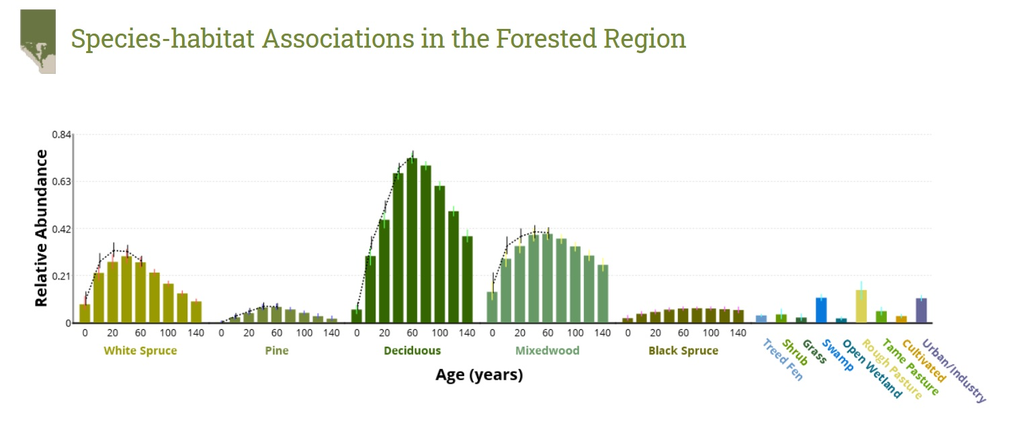

Figure 1.1: Example of species-habitat associations for Ovenbird from the AMBI and Boreal Avian Modeling Project.

The WBP study area is large and it includes a significant heterogeneity of plant communities. However, specific characteristics are shared among the different provinces as established by Canada’s Ecological Framework (“The Ecological Framework of Canada. Ecozone and Ecoregion Maps and Descriptions,” n.d.). Based on this information, it was decided that the study area should be divided into several sub-regions, to allow each region to be examined based on the most appropriate land cover classification system. We, therefore, aimed to:

*1) Determine an appropriate manner to divide the Western Boreal Project study area into sub-regions.* and

*2) Delineate a set of appropriate, ecologically meaningful land cover categories and age classes for each sub-region.*

# 2 Methods

We carried out an extensive literature review of both materials describing the vegetation found in the study area and the different methods used to classify cover classes. The local forest inventories allowed us to list the species and species assemblages described and used for vegetation categorization within potential sub-regions of interest for this project, and the stand-age classes most commonly used (The Forestry Corp 2004; Saskatchewan Environment 2004; Resource Information Management Branch. Alberta Sustainable Resource Development 2005; Forest Resources 2006; Lisgo et al. 2008; Forest Management Branch 2016). The studies at national level allowed us to corroborate the hierarchical vegetation categorization of forested lands and the different ways in which stand age is classified (Power and Gillis 2006; Cosco 2011).

As the main objective of the project is focused on birds, we used Bird Conservation Regions (BCR) and the Province boundaries to obtain a sub-region division of the study area (Environment Canada 2013). From this, we determined firstly, which potential BCR/Province groupings had the most similarities and would allow available bird data coverage from the Boreal Avian Modelling Project (BAM) to be equitably divided, and then, once sub-regions were determined, which land cover classes were most important in each one (Cumming et al. 2010; Barker et al. 2015).

The land cover classification classes for each sub-region were obtained using the Land Cover Classification of Canada 2005 (LCC05) (Latifovic et al. 2008). LCC05 has 39 habitat categories. Categories 1 to 15 represent forested classes and 16 to 39 non-forested ones. Stand-age distribution was obtained from Natural Resources Canada(Beaudoin et al. 2017).

# 3 Results

## 3.1 Sub-regions

The Western Boreal study area was divided into sub-regions following the BCR boundaries, except for BCR 6, which given its extensive size and vegetation heterogeneity, it was split into three sub-regions: the northern area in Yukon, the Northwest Territories and Nunavut, the western area in British Columbia and Alberta, and the eastern area in Saskatchewan and Manitoba (Fig.3.1).

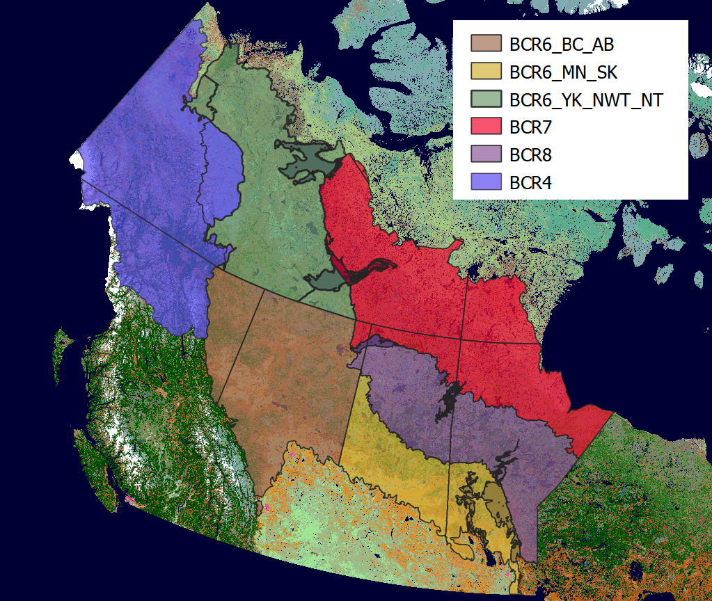

Figure 3.1: Western Boreal Project sub-regions

## 3.2 Land Cover Classes

In each of the sub-regions, the relative frequency of Land Cover Classes was as follows:

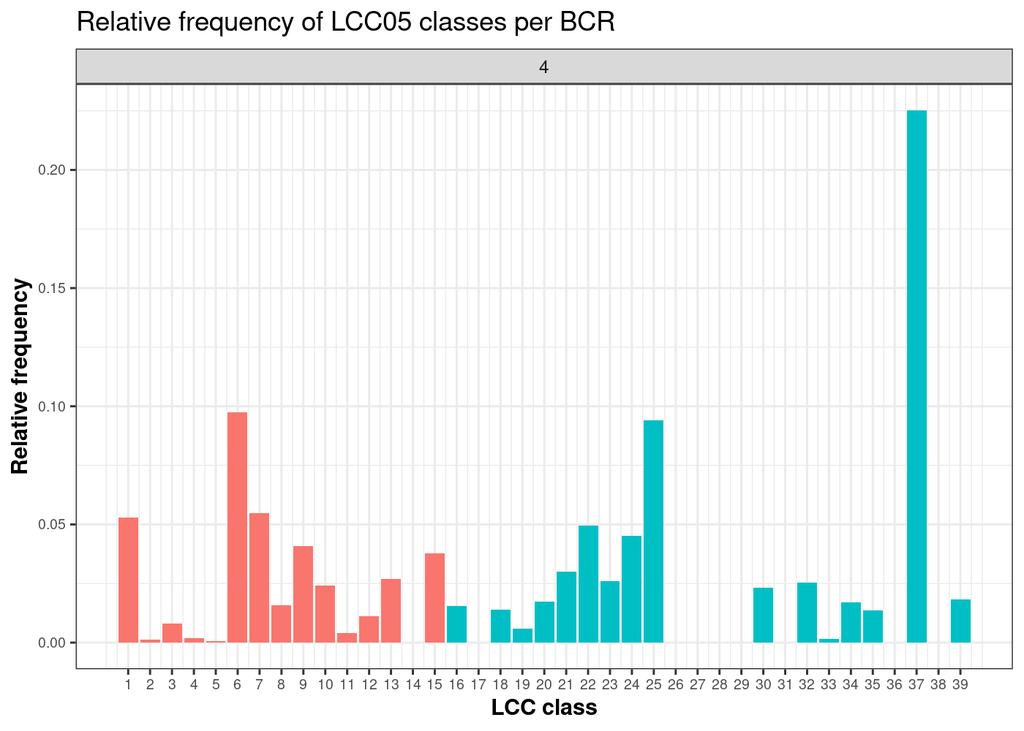

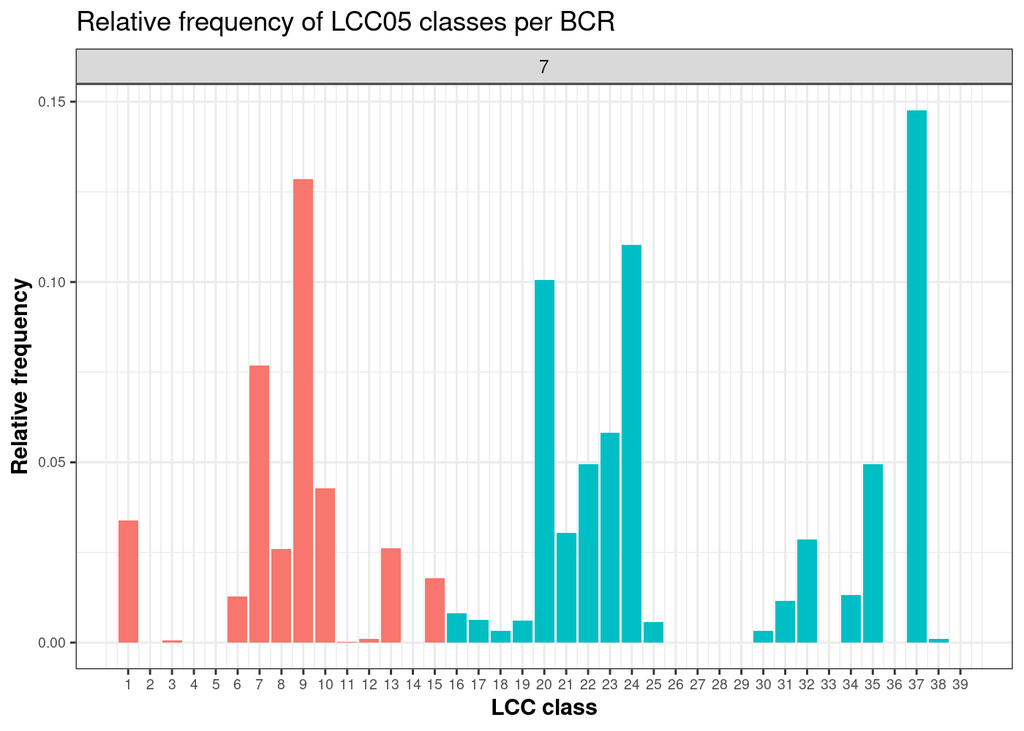

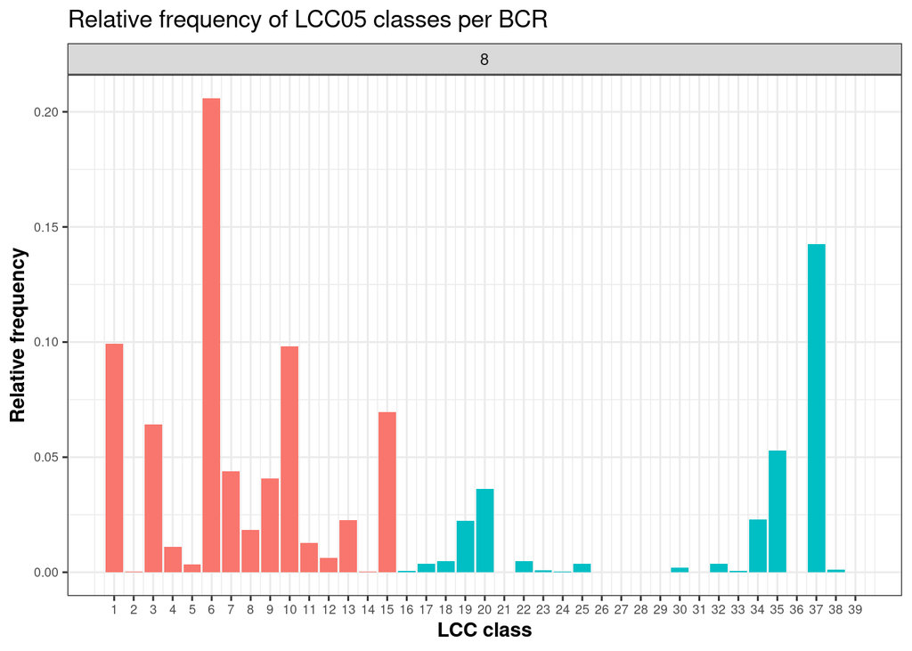

Figure 3.2: Relative frequency of Land Cover Classes for BCR’s 4, 7, and 8, respectively.

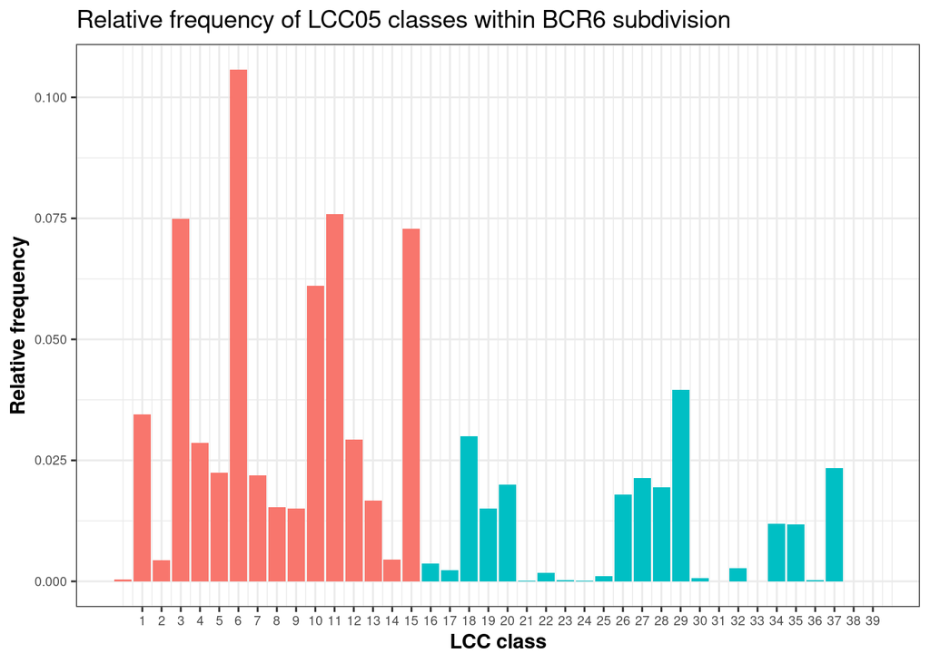

Figure 3.3: Relative frequency of Land Cover Classes for BCR 6.

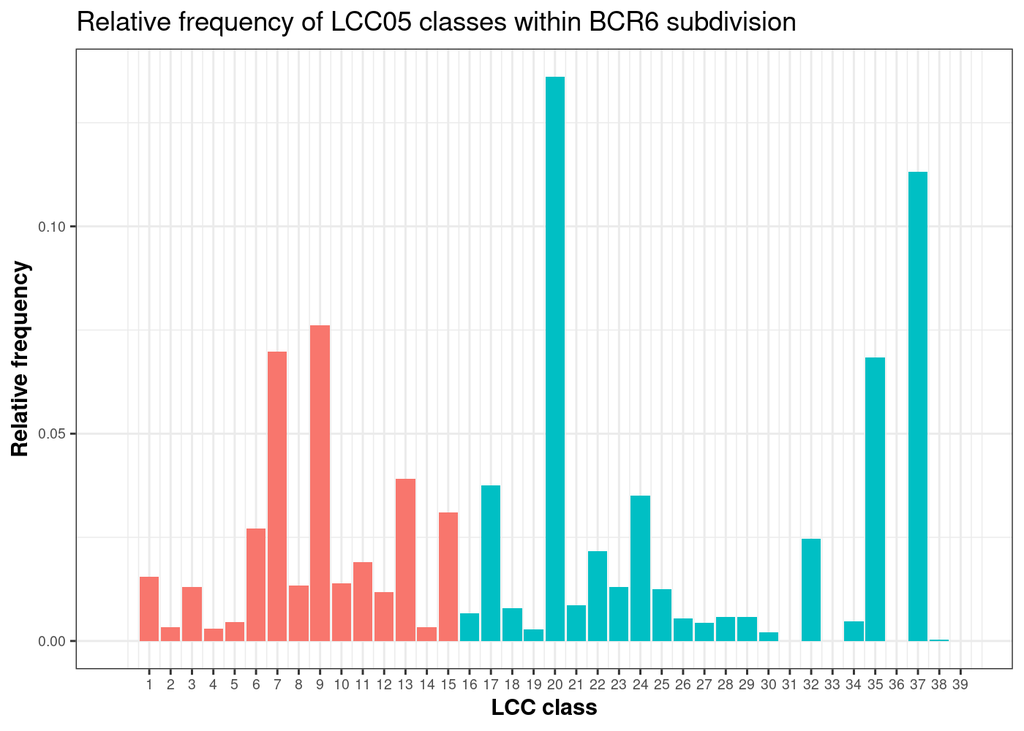

Figure 3.4: Relative frequency of Land Cover Classes for BCR 6.

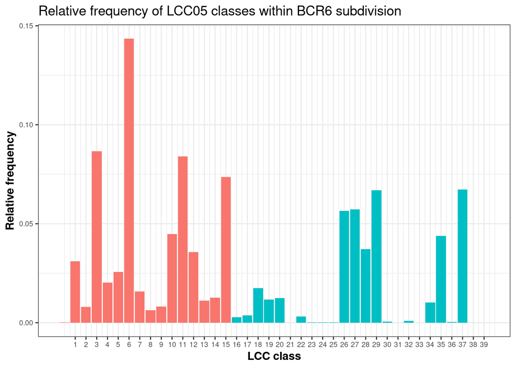

Figure 3.5: Relative frequency of Land Cover Classes for BCR 6.

Based on the relative frequency of land cover classes and our literature review of vegetation groupings, we determined that the following forested categories should be included for each sub-region.

## 3.3 BCR 6 in British Columbia and Alberta

Table 3.1: Forest Cover types description for BCR 6:*British Columbia and Alberta*. Modified from Mahon((2016)).

[output not shown]

## 3.4 BCR6 in Northwest Territories and Yukon

Table 3.2: Forest Cover types description for BCR 6:*Northwest Territories and Yukon*.

| Forest Cover Type | Description |
| --- | --- |
| Spruce dominant | Spruce stands where the combined spruce component is 80% or more. |
| Deciduous dominant | Stands where the deciduous tree component is 80% or more. |
| Coniferous mix | Coniferous trees component is 80% or more. |
| Coniferous/deciduous mix | Mixed stands where neither deciduous or coniferous component is 80% or more. |
| Forested wetland | Lowland-wetland with poor drainage and tree cover sparse at 40% or less, where black spruce and larch species component is 80% or more. Moss, lichen and/or herb understory. |

## 3.5 BCR 6 in Saskatchewan and Manitoba

Table 3.3: Forest Cover types description for BCR 6:*Saskatchewan and Manitoba*.

| Forest Cover Type | Description |
| --- | --- |
| Deciduous dominant | Stands where the deciduous tree component is 80% or more. |
| Coniferous dominant | Coniferous trees component is 80% or more. |
| Coniferous/deciduous mix | Mixed stands where neither deciduous or coniferous component is 80% or more. |
| Other hardwoods | Rarer hardwoods such as green ash, Manitoba maple or white elm comprise 20% or more. |
| Forested wetland | Lowland-wetland with poor drainage and tree cover sparse at 40% or less, where black spruce and larch species component is 80% or more. Moss, lichen and/or herb understory. |

## 3.6 BCR 4

Table 3.4: Forest Cover types description for BCR 4.

| Forest Cover Type | Description |
| --- | --- |
| Spruce/Fir dominant | Spruce and fir stands where the combined spruce and fir component is 80% or more. |
| Pine dominant | Lodgepole or jack pine stands where the pine component is 80% or more. |
| Deciduous dominant | Stands where the deciduous tree component is 80% or more. |
| Coniferous mix | Coniferous trees component is 80% or more. |
| Coniferous/deciduous mix | Mixed stands where neither deciduous or coniferous component is 80% or more. |
| Forested wetland | Lowland-wetland with poor drainage and tree cover sparse at 40% or less, where black spruce and larch species component is 80% or more. Moss, lichen and/or herb understory. |

## 3.7 BCR 7

Table 3.5: Forest Cover type description for BCR 7.

| Forest Cover Type | Description |
| --- | --- |
| Stunted coniferous | Tree cover sparse at 40% or less with stunted spruce, larch and jack pine species making up 80% or more. Understory largely lichen and rock. |
| Coniferous mix | Coniferous trees component is 80% or more. |
| Coniferous/deciduous mix or deciduous dominant | Stands where coniferous component is not 80% or more. |
| Forested wetland | Lowland-wetland with poor drainage and tree cover sparse at 40% or less, where black spruce and larch species component is 80% or more. Moss, lichen and/or herb understory. |

## 3.8 BCR 8

Table 3.6: Forest Cover type description for BCR 8.

| Forest Cover Type | Description |
| --- | --- |
| Spruce dominant | Spruce stands where the combined spruce component is 80% or more. |
| Deciduous dominant | Stands where the deciduous tree component is 80% or more. |
| Coniferous mix | Coniferous trees component is 80% or more. |
| Coniferous/deciduous mix | Mixed stands where neither deciduous or coniferous component is 80% or more. |
| Forested wetland | Lowland-wetland with poor drainage and tree cover sparse at 40% or less, where black spruce and larch species component is 80% or more, underlain by moss, lichen and/or herb understory. |

## 3.9 Non-forested Types

we determined that given each of the sub-regions within the WBP the following non-forested classes were sufficient for all subregions.

Table 3.7: Non-forested types description for the WBP.

| Non-Forested Type | Description |
| --- | --- |
| Water/Ice | Lakes and rivers, or consistente snow/ice cover throughout the year. |
| Wetland | Areas of poor drainage, with vegetation, but less than 5% tree cover. |
| Anthropogenic/Exposed land | Non-forested land. No cover of any type. |
| Grass/Cropland | Non-forested land. Herbaceous grassland or herbaceous cover. |
| Shrubland | Non-forested land. Open shrubs or closed shrubs. |
| Bryoid | Non-forested land. Bryoid cover. |

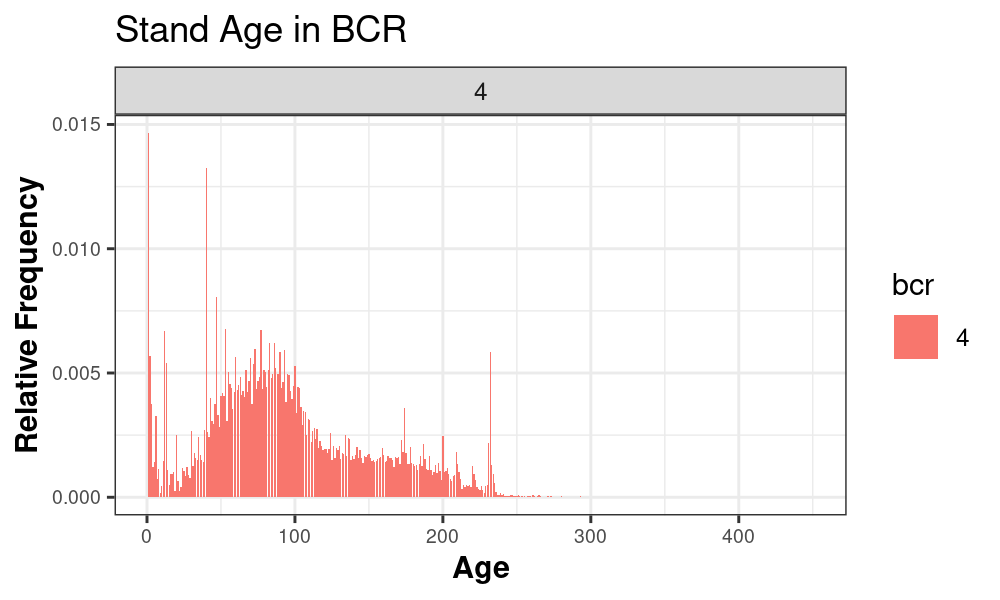

Figure 3.6: Age Frequency for BCR 4, 6, 7 and 8.

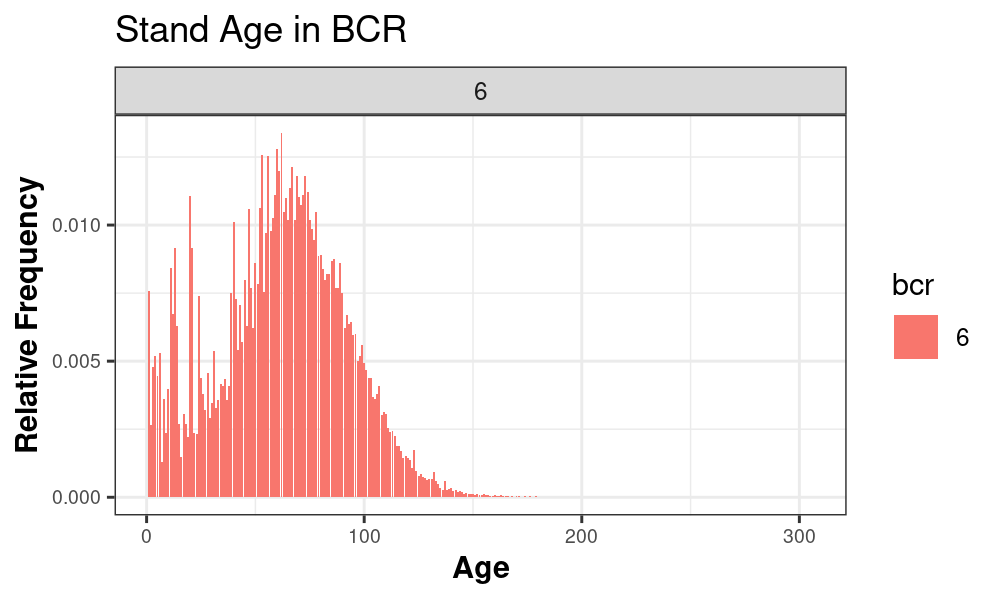

Figure 3.7: Age Frequency for BCR 4, 6, 7 and 8.

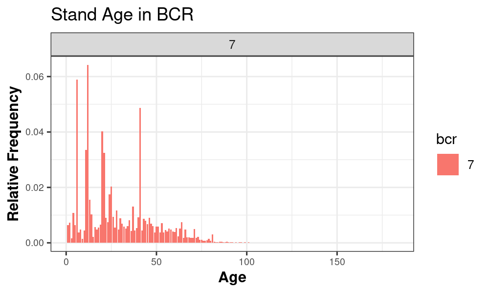

Figure 3.8: Age Frequency for BCR 4, 6, 7 and 8.

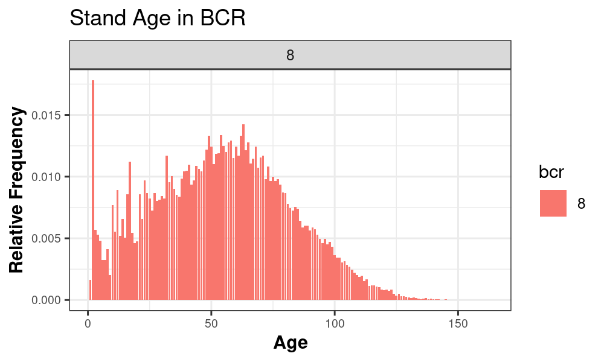

Figure 3.9: Age Frequency for BCR 4, 6, 7 and 8.

## References

Alberta Biodiversity Monitoring Institute, and Boreal Avian Modelling Project. 2019. “Ovenbird.Seiurus Aurocapilla.”

Barker, Nicole, Patricia Fontaine, Steven Cumming, Diana Stralberg, Alana Westwood, Erin M. Bayne, Péter Sólymos, Fiona K. A. Schmiegelow, Samantha J. Song, and David Rugg. 2015. “Ecological Monitoring Through Harmonizing Existing Data: Lessons from the Boreal Avian Modelling Project.” *Wildlife Society Bulletin* 39 (3): 480–87.

Beaudoin, A., P. Y. Bernier, P Villemaire, L Guindon, and XJ. Guo. 2017. “Species Composition, Forest Properties and Land Cover Types Across Canada’s Forests at 250m Resolution for 2001 and 2011.” Quebec, Canada: Natural Resources Canada, Canadian Forest Service, Laurentian Forestry Centre.

Cosco, Jonh. 2011. “Common Attribute Schema (CAS) for Forest Inventories Across Canada.” Boreal Avian Modelling Project and Canadian BEACONs Project.

Cumming, S. G., E. Bayne, F. K. A. Schmiegelow, T. Fontaine, S. J. Song, and K. Lefevre. 2010. “Toward Conservation of Canada’s Boreal Forest Avifauna: Design and Application of Ecological Models at Continental Extents.” *ERA*. https://doi.org/10.7939/R3Z31NW3X.

Environment Canada. 2013. “Bird Conservation Strategy for Bird Conservation Region 4 in Canada: Northwestern Interior Forest.”

Forest Management Branch. 2016. *Yukon Vegetation Inventory Manual, Version 2.1.*

Forest Resources. 2006. “Northwest Territories Forest Vegetation Inventory Standards with Softcopy Supplements. V. 3.0.” Forest Management Division, Dept of ENR.

Latifovic, R, I Olthof, D Pouliot, and J Beaubien. 2008. “Land Cover Map of Canada 2005 at 250 M Spatial Resolution.” *Natural Resources Canada/ESS/Canada Centre Fro Remote Sensing*. ftp://ftp.ccrs.nrcan.gc.ca/ad/NLCCLandCover/LandcoverCanada2005_250m/.

Lawler, Joshua J., Raymond. J. O’Connor, Carolyn T. Hunsaker, K. Bruce Jones, Thomas R. Loveland, and Denis White. 2004. “The Effects of Habitat Resolution on Models of Avian Diversity and Distributions: A Comparison of Two Land-Cover Classifications.” *Landscape Ecology* 19 (5): 515–30. https://doi.org/10.1023/B:LAND.0000036151.28327.01.

Lisgo, K, Steve Cumming, N. Flynn, and F. K. A Schmiegelow. 2008. *Evaluation of Saskatchewan Designated Protected Lands as Ecological Benchmarks for Forest Management*.

Mahon, C. Lisa, Gillian Holloway, Péter Sólymos, Steve G. Cumming, Erin M. Bayne, Fiona K. A. Schmiegelow, and Samantha J. Song. 2016. “Community Structure and Niche Characteristics of Upland and Lowland Western Boreal Birds at Multiple Spatial Scales.” *Forest Ecology and Management* 361 (February): 99–116. https://doi.org/10.1016/j.foreco.2015.11.007.

Power, Katja, and Mark Gillis. 2006. *Canada’s Forest Inventory 2001*. Victoria, BC: Natural Resources Canada. Canadian Forest Service. Pacific Forestry Centre.

Resource Information Management Branch. Alberta Sustainable Resource Development. 2005. “Alberta Vegetation Inventory Interpretation Standards Version 2.1.1. - March 2005,” 99.

Saskatchewan Environment. 2004. *Saskatchewan Forest Vegetation Inventory*. Prince Albert, SK: Forest Service Saskatchewan.

Tews, J., U. Brose, Volker Grimm, K. Tielbörger, Matthias C. Wichmann, M. Schwager, and F. Jeltsch. 2004. “Animal Species Diversity Driven by Habitat Heterogeneity/Diversity: The Importance of Keystone Structures.” *Journal of Biogeography*, no. 31: 79–92. https://doi.org/10.1046/J.0305-0270.2003.00994.X.

“The Ecological Framework of Canada. Ecozone and Ecoregion Maps and Descriptions.” n.d. http://ecozones.ca/english/zone/index.html.

The Forestry Corp. 2004. “FLI User Guide, Prepared for Louisiana Pacific Canada Ltd. And Manitoba Conservation.” In. Edmonton, AB.